# 1 . Arena Automation System

This guide documents the use of the suite of hardware and software tools that collectively facilitate the automatic, unsupervised recording and analysis of dragonfly activity during whole-day recording sessions. This collection of interrelated tools shall be referred to as the *Arena Automation System,* or **AAS**.

For more information about how to update this documentation, read the "About the documentation" section.

[output not shown]

## 1.1 . Practical step-by-step guide

### 1.1.1 . General setup

1. Launch the *Arena Automation Web Interface*

   This will bring up a command window that will stay open, and can be minimized to the background:

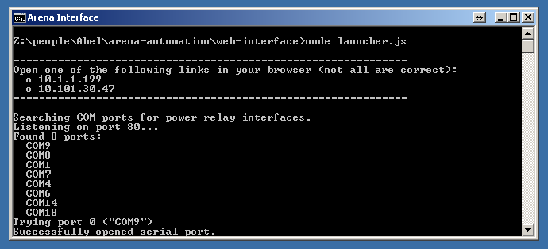

3. Now open a browser (still on the Photron PC), and navigate to "http://localhost." (Note that depending on the network configuration, this same web interface can be viewed on other computers using the Photron PC's IP address.)

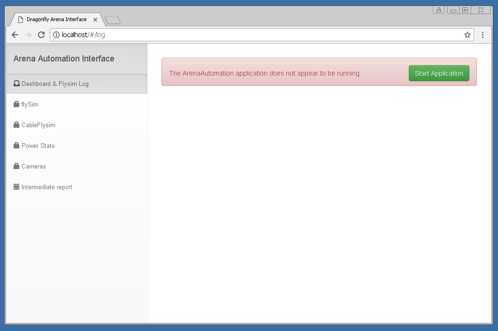

4. Now click on "Power" in the side menu, which opens the following page:

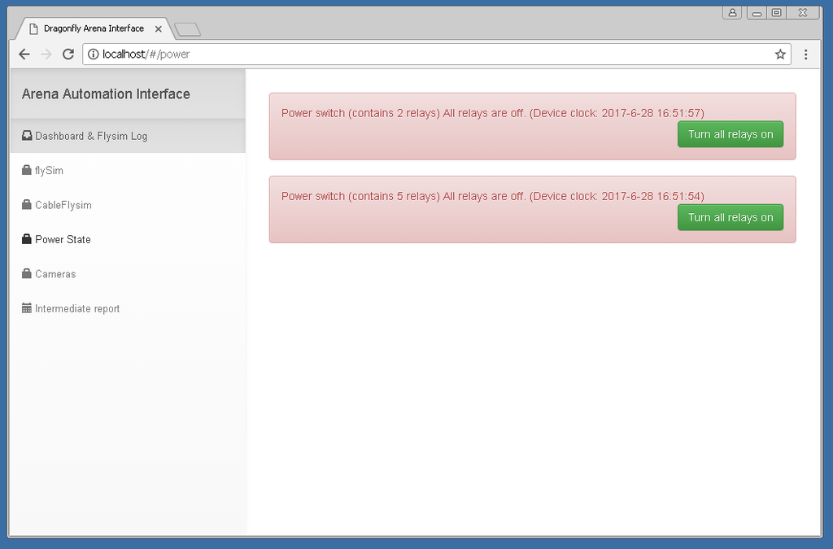

5. Click both buttons to power on the motion capture cameras, the Photrons, the FlySim motors, and the Telemetry --- assuming all these are connected and the power relays are not manually turned off. The sysem will indicate when the power is on:

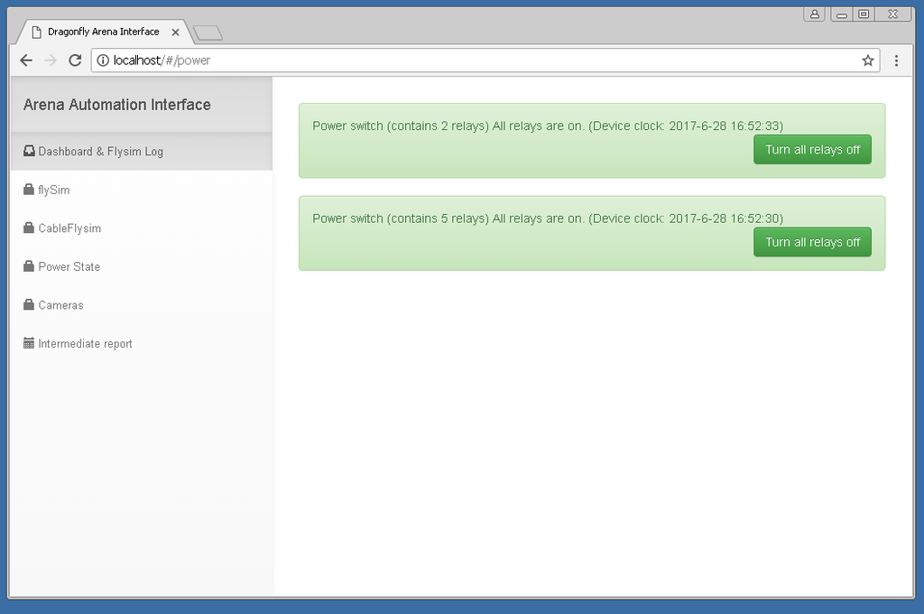

### 1.1.2 . Cortex setup

1. Wait ~20 seconds to ensure all cameras have started. Then, on the Cortex PC, start Cortex 3.6.

[figure not shown]

2. Upon startup, Cortex will load the most recently used configurations. In order not to overwrite the previous calibration settings, data, etc., we re-save the setup configuration in a new directory:

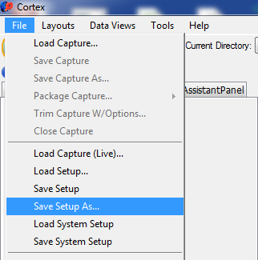

3. As data files will be saved to the same folder as the setup file (*.cal), we save each setup file to a new directory. For consistency, and to ensure automatic analysis scripts work, this directory should be created in the same "MoCap raw" directory as the other recordings. The convention is to name the directory according to the "yymmdd" (year-year-month-month-day-day) format, although this is not technically required.

   For consistency, we name the *.cap file according to the "yymmdd_precal.cap" format, to indicate the settings are "pre-calibration" (i.e. copied from the previous recording).
4. Connect to the cameras, then click "All On."

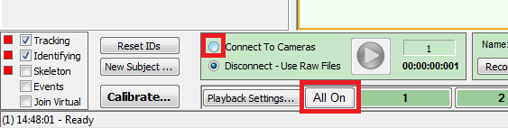

5. Turn off the arena humidifier. It will increase calibration errors. We will turn it on again after calibration.
6. Place the calibration wand in the middle of the arena.
7. Place small pieces of black cloth over the perches and LED Sync box, to ensure none of their markers are confused for the wand, which would increase calibration errors.
8. Adjust the minimum marker size to 21:

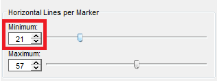

9. Adjust thresholds on each camera to ensure only the 3 wand markers are seen. Make sure all (enabled) cameras will see at least some valid 3-marker frames, or otherwise the calibration will fail (diverge).
10. Calibrate. Be sure to cover the entire camera volume during wanding. In addition, it is a good idea to split your wanding procedure into three subroutines, each aligned to one of the orthogonal axes. This minimizes the colinearity of wand measurements, and maximizes the 3D calibration accuracy.
11. After calibration, save the current setup as "yymmdd_cal1.cap" in the same directory. For future calibrations throughout the day, continue the "yymmdd_calN.cap" format, where N is increased every time.

### 1.1.3 . Photron setup

[figure not shown]

3. Photron receives its sync signal from the signal generator. The signal generator produces two frequencies: One for the Photron cameras, and one of the MAC/Mocap cameras. Be sure these frequencies are set correctly.
4. We now tell the Photrons to listen to this external clock:

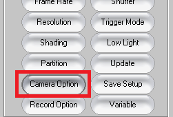

   Then select "TRIG POS" for "TRIG TTL IN," and "ON OTHERS POS" for "SYNC IN."

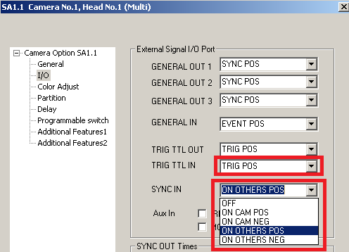

5. Set the correct shutter value, e.g. 1000 Hz:

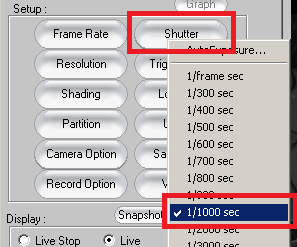

6. If we are gathering real fly trajectories, or otherwise need accurate Photron 3D reconstruction, we need to calibrate the Photron cameras as well.
   1. If L-frame recording is required, do the following. **Note:** This is currently not required, and the same Lframe dataset can be re-used. A secondary registration transformation will align the Cortex and Photron coordinate systems, thus overriding the L-frame.
      2. Place the L-frame in the center of the arena, and place all batteries in the battery-holder to light up the 4 LEDs.
      3. Press the record button. A window pops up. Select (and create, if it doesn't already exist) a new directory for this day's recordings. This directory should be in the same directory as the other Photron recording directories, in order for the automatic analysis scripts to find the files. Be sure to un-select "Info Save". Relevant settings are illustrated below:

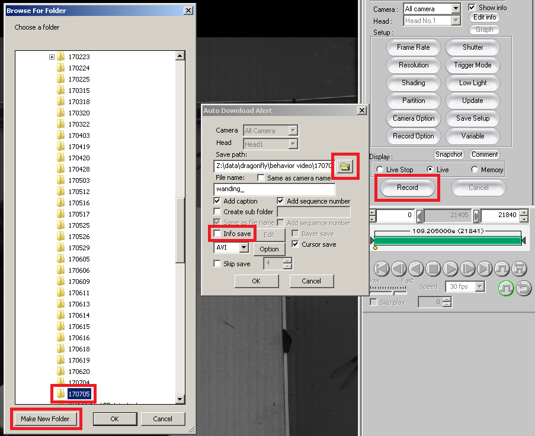

      4. The "record" button will switch to "trigger in".
      5. Click it again. The button will display "recording" to indicate that frames are being recorded. After ~1 second, press "Recording Done" to stop the recording
      6. Switch to the "Data Save" tab, reduce the range of frames to e.g. 100, and save the file as e.g. "lframe_N.avi".

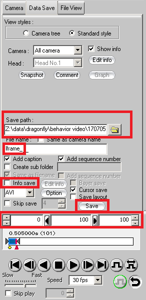

      7. Now remove the L-frame from the arena. Put the wand back in the arena --- the one we used to calibrate Cortex. As before, make sure the minimum marker size and thresholds are set correctly.
   2. Now ensure that Photron is in "Start Trigger" mode:

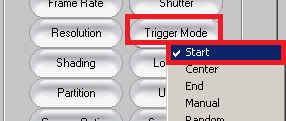

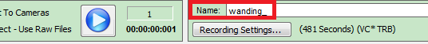

   5. Now configure the recording settings, which are specific to this wanding recording:

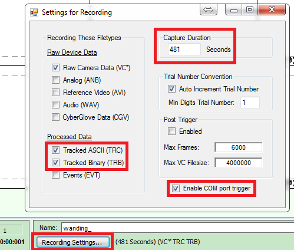

   6. Now open the arduino program.
   7. Then select the right serial port (currently "COM 4"):

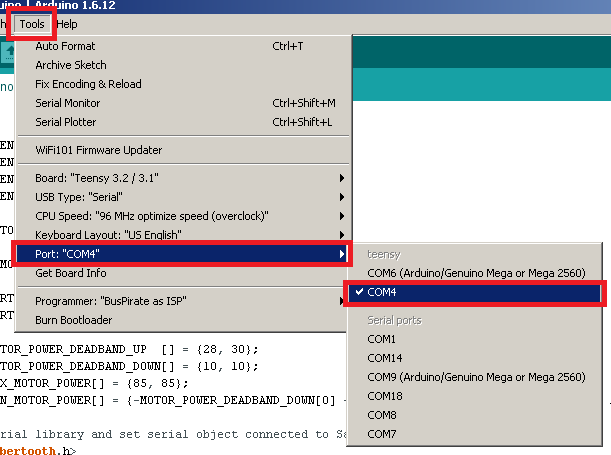

   8. Now open the Serial Monitor:

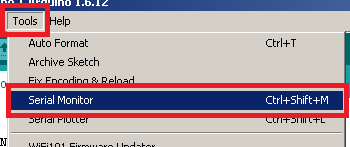

   9. If this is the right COM port, an "h" command should identify the device as the "Teensy TTL Controller":

[figure not shown]

   10. Copy the "Wand200.mars" markerset file into the current Cortex directory, i.e. the one we created earlier, and in which our current setup file is saved. The "Wand200.mars" file can be found by searching for Wand200.mars in the "MoCap raw" directory.
   11. Load the "Wand200" markerset into Cortex:

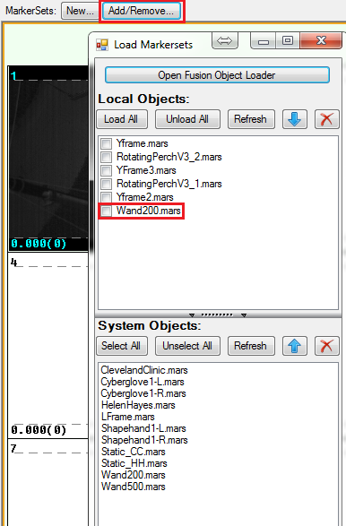

   12. Now both Cortex and Photron are armed and listening for triggers, and the wand is in the center of the camera volume, and is correctly recognized by Cortex.
   13. Send a "t" command in the Serial Monitor window. This will trigger the start of both Cortex and Photron recordings.
   14. Wave the wand in the same pattern as we used to calibrate the Cortex volume. 40-60 seconds of recording should be sufficient.
   15. Manually end both recordings by clicking the red recording button in Cortex, and clicking "recording done" in PFV.
7. We are now ready to arm Photron for recording.

### 1.1.4 . SpikeGL setup

1. If Telemetry data needs to be acquired, SpikeGL should be started as well.
2. Currently two versions of SpikeGL are available.
   - **2016 version**: C:/Users/leonardo/Desktop/SpikeGL_StimGL_64Bit_Qt5/
   - **Most Recent version**: Z:/people/Abel/SpikeGL/release
3. The 2016 version is currently most stable, but does not save sufficient data to accurately reconstruct the timing of those telemetry data frames arriving before the hardware TTL trigger.
4. The most recent version does save the relevant data, and should be used in the future.

   **Note**: Currently a (presumably minor) bug is causing a slowdown of the SpikeGL software, leading to delayed saving of data, making the program difficult to use. This bug is being actively investigated at the moment and this notice will be updated as soon as the fix is made.
5. To start SpikeGL, run the relevant "SpikeGL.exe" executable in one of the above directories.

[figure not shown]

6. In the window that appears, press "b", or click "New Bug Acquisition" in the "File" menu.

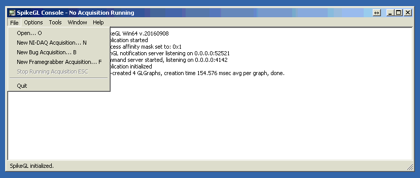

7. Ignore "AO Device Invalid" notifications.

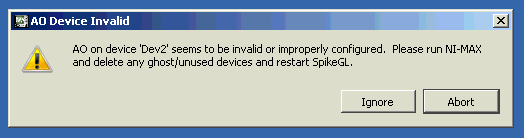

8. Configure the Telemetry Acquisition.
   2. In particular, click "Browse" to choose an appropriate filename. For consistency, create a new directory in the "year-year-month-month-day-day" format, and select "year-year-month-month-day-day_telemetry_1.bin" as the filename.
   3. Ensure the correct TTL line inputs are selected for recording, and that the right TTL input is selected as the trigger. The current trigger input (TTL 4) is currently selected by default.
   4. Select the right prepend/append duration that will be recorded around the TTL center trigger.
   5. Select the sampling rate.
   6. Click "OK"

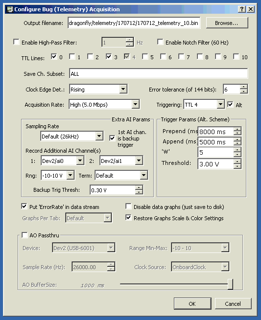

9. Select "Yes" when asked to "Resume filename counting."

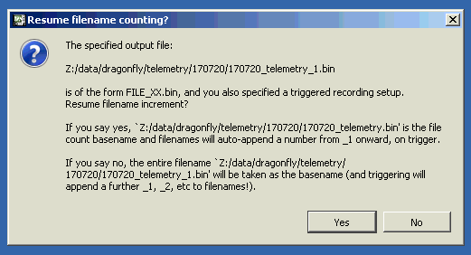

10. Two SpikeGL windows will now appear. No data will be displayed, as the Transceiver power has not yet been turned on.

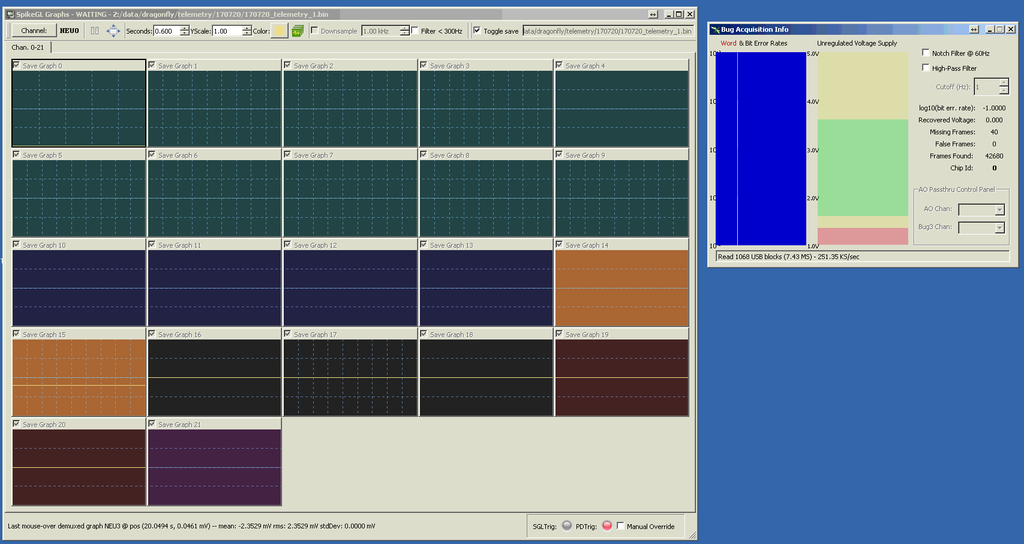

11. Before turning on the Telemetry Transceiver, **ensure that the antenna is connected to the Transceiver!** If the Transceiver is turned on without a connected antenna, this can in principle seriously harm the device.
12. Ensure there are no significant metal objects in the antenna volume. Although small metal parts are ok, especially when farther removed from the antenna, large metal sheets can in theory reflect power back into the Transceiver and negatively affect its long-term performance.
13. Now turn on the Transceiver power. If a backpack is in range, data should start appearing in both data graph windows.
14. Every time a trigger is received, a new triplet of files (.bin, .meta and .bug3) will be written to the chosen data directory.

### 1.1.5 . Flysim setup

1. Open a Serial command interface to the FlySim controller.
2. Send an "h" command the confirm this is indeed the FlySim controller.
3. Send the command "z 400" to raise FlySim to a height of ~400 mm.

   **Note**: Due a small bug, it appears that sometimes the FlySim Controller doesn't respond to Z commands unless a "position" command is first sent directly to the FlySim Z controller. Only one such command seems to fix the error. This bug should be fixed soon. More info below on how to interface with the FlySim Z controller.
4. Now send the command "tune." Within a few seconds, you should see the motors will start to shoot the artificial bead back and forth.
5. Wait approximately 60 seconds for the tuning sequence to complete.
6. Now manually, or using the power interface explained above, power down the device.
7. After a few seconds, power the device back on. This power cycling is required by the Kangaroo motor driver that controls the X axis, and ensures the newly calibrated settings are written to and loaded from memory.
8. The next FlySim commands are best sent through the Arena Automation Web Interface.
9. Be sure to close the Arduino IDE instance associated with this Serial Interface, or otherwise be sure to close the Serial command window and interface. This ensures that *ArenaAutomation.exe* can establish a connection with the FlySim controller.
10. After the Arduino IDE serial interface is closed, and *ArenaAutomation.exe* has been started as described below, FlySim commands can be sent using the Arena Automation Web Interface, again as described below.

### 1.1.6 . General setup, continued

   This also brings up a command line window that can be minimized:

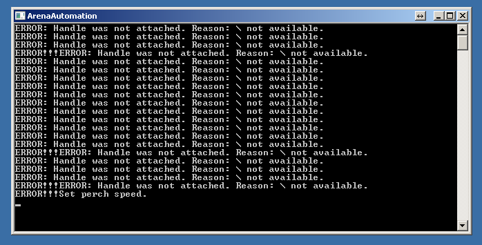

5. Now go back to the browser, and navigate to the "Log" page in the web interface. This page opens by default when you navigate to "localhost." This page will now display log information:

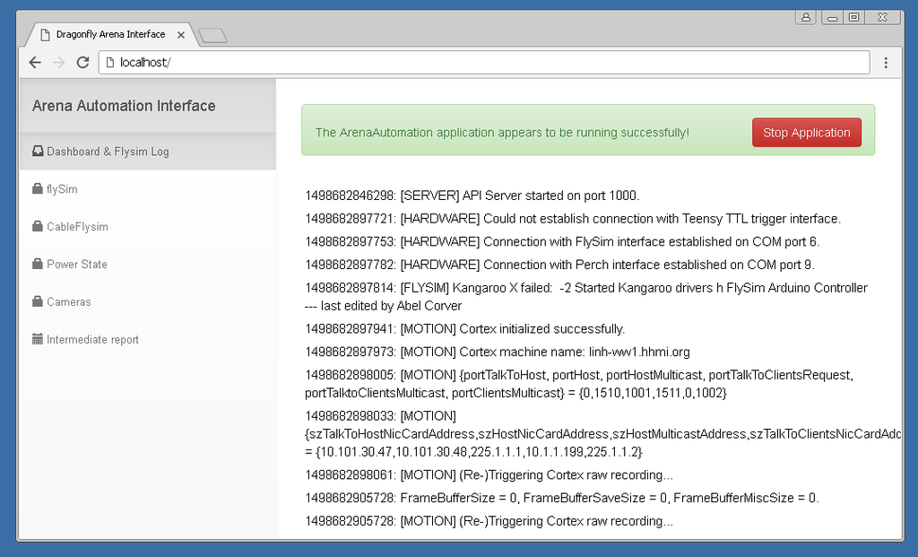

6. We can now navigate to the FlySim interface to send commands to FlySim:

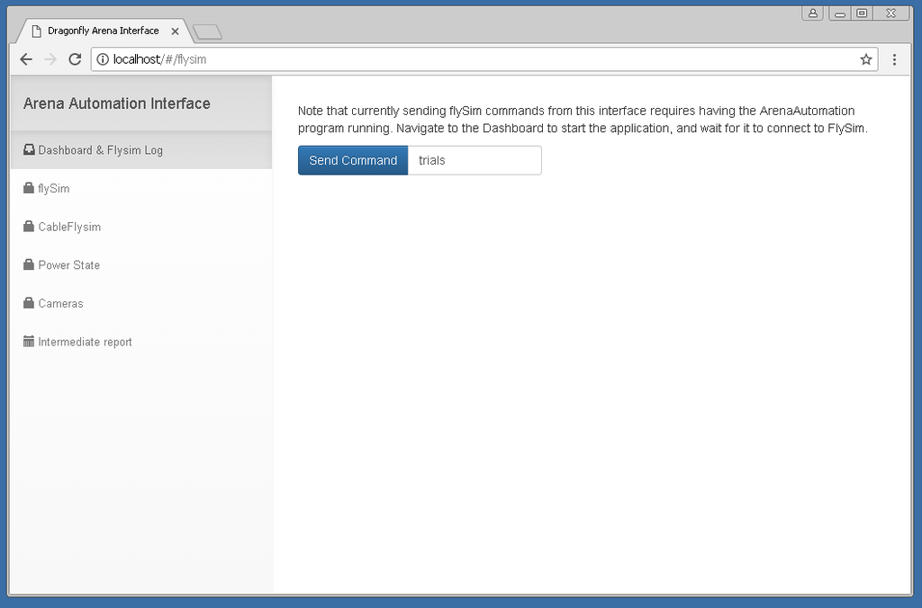

7. The experiment will now run itself! Although the system is automated, it is good practice to check in on the system every 2 hours. This can be done remotely, minimizing the time this takes. Among the relatively rare system failures, common failure modes include (i) a Cortex crash,
   2. rare but occasional crashes in the core ArenaAutomation.exe process, and (iii) FlySim crashes. Crashes of either Cortex or the main ArenaAutomation.exe process will be obvious, indicated by the faded window and likely a Windows error dialog. A failure to present flysim trials, e.g. due to some occasional motor failure, will be indicated in the log window.
8. To turn the system off at night, log into the Photron PC remotely using TeamViewer, navigate to the power web interface as illustrated above, and click the buttons to turn off the relays. Be sure to actually close the ArenaAutomation.exe console window, to ensure that the data files are no longer being written to.

### 1.1.7 . post-processing

#### 1.1.7.1 . Automatic, single-click post-processing

1. To commence post-processing, navigate to the "*arena-automation*" directory, and click the "*.bat*" file "*auto-update-analysis.bat*".
2. This will merge recording fragments taken on a given day into a single directory and data file for each day.
3. It will subsequently do the following:
   2. **Correct frame indices:** This ensures that each Mocap frame has a unique frame ID. Duplicate indexes are created when Cortex is restarted, either as a result of clicking the start/stop recording button, or by closing and re-opening the Cortex program.
   3. **Extract raw (.vc) camera data**: The raw cameras data is gathered from data files in the Cortex data directory. The raw camera data is then indexed by *uncorrected* frameID and timestamp, and is then matched to the *corrected* frameIDs above.

      The Cortex data is then integrated into a new "*.msgpack*" data file (with the new extension "*.raw.msgpack*"), that now contains both XYZ and raw XY camera data. The Arena Automation System contains a utility script (util.py) to easily browse this raw data.
   4. **Extract mocap (LED) triggers**: The system then searches for a signal from the LED Sync Box, and saves recognized triggers to file.

      By default, the search system will only search for LED Sync signals that occur close in time to the trigger timestamps saved by the core *ArenaAutomation.exe* program in the real time log file.

      However, the script can be easily switched to searching for triggers in all files, though this will take a few hours for an all-day recording.
   5. **Extract real-time log**: The "*ArenaAutomation.exe*" software write a log file during its real-time processing. This log file contains such things as detected takeoffs, any hardware triggers sent, presented trials, state of internal buffers, etc. During extraction, this log is converted from an internal SQL database format to a plain text file. In addition, the FlySim trials log output is parsed, and a "*.trials.csv*" file is produced with statistics on e.g. height and velocity of presented trials.
   6. **Extract FlySim trajectories**: The system then searches for FlySim trajectories. The key signature of a FlySim trajectory is a series of markers (unidentified by Cortex) that are contiguous in space and time. The system currently further checks for linearity, but this condition can be removed if in the future non-linear trajectories are used.
   7. **Extract takeoffs / perching locations**: The system then searches for Yframe trajectories, in particular those that are preceded by a few (currently at least 2) seconds of perching. This way, we can quickly distinguish between trajectories that merely correspond to a dragonfly flying through the volume, versus those where a dragonfly actually pursued a prey.

      Conversely, the system saves those datapoints at which the dragonfly was sitting still, prior to takeoff. This can be used to plot heatmaps of preferred perching locations, etc.
   8. **Extract telemetry**: The system then searches for telemetry files (in the default telemetry data directory) corresponding to the mocap data in the "*.msgpack*" master file. This correspondence is based on timestamp.

      The relevant "*.meta*", "*.bin*", and "*.bug3*" files are post-processed into a single, trigger-aligned table.

      Subsequently, the system searches for matches between the mocap (LED) triggers, and the telemetry triggers, based on system clock timestamps. When a match is found, the telemetry and mocap data are time-aligned into a single table, and this table is saved as a "*.csv*" file. This file will likely form the basis of most analyses, and represents the key output of the entire automation system.
   9. **Extract high-speed video**: Subsequently, the system will look for high-speed video files that occurred at the same time as the mocap trigger (again based on system clock timestamps), and merges the filename of the corresponding high-speed video file into the "*.csv*" output of the telemetry extraction step.

      **At this point, the most important analyses are essentially done!**
   10. **Generate reports**: Subsequently, the system will generate HTML reports that interactively present the detected takeoff (and FlySim) trajectories. This allows quick debugging of the processing pipeline, and gives one a sense of what happened in the arena.

       In addition, the reports include heatmaps of perching locations, and statistics about the types of FlySim trials that were presented.

       The HTML report system is highly extensible, and different types of plots can be added in the future.
   11. **Extract markersets**: Independently of the other scripts, the system will also output a "*.csv" file containing the XYZ locations of various markers, as well as the corresponding markerset name. This allows easy plotting of e.g. Yframe trajectories in e.g. Matlab. Note that all this information is contained in the "*.msgpack*" files, and this "*.csv" file is therefore redundant.

##### 1.1.7.1.1 . The final output data files

Relevant data files can be found in the following directories:

1. **Behavior video data directory**: Z:/data/dragonfly/behavior video/< date >/
2. **Telemetry data directory**: Z:/data/dragonfly/telemetry/< date >/
3. **Main data directory**: Z:/people/Abel/arena-automation/data/< date >/

At the end of all post-processing, you will (or can, if the relevant script was executed) encounter the following files in the main data directory:

- **< date >.msgpack**: The original data file
- **< date >.log**: The original log file
- **< date >.msgpack.index**: The index file that is always created when any script accesses the .msgpack files. The index facilitates randomly accessing frame by frame index and timestamp.
- **< date >.takeoffs.csv**: This file contains the frame ranges of the putative takeoff events.
- **< date >.tracking.csv**: This file is associated with the *.takeoffs.csv* file, and contains XYZ marker data for the takeoff events in question.
- **< date >.mocap.csv**: This file contains only those trajectories deemed to be genuine takeoff trajectories of interest --- based on the span of the trajectory, and the duration of perching just prior to takeoff. It is essentially a subset of *.tracking.csv*. It includes all three vertices of the Yframe, as well as FlySim data.
- **< date >.mocap.all.csv**: This file contains all the data in *.mocap.csv*, but also includes all other unidentified XYZ markers.
- **< date >.perches.csv**: This file is the dual of *.takeoffs.csv*, and contains stretches of continuous perching.
- **< date >.perch_objects.csv**: This file contains locations of the recognized perch object markersets. This file is not used much anymore, but can be used to easily plot the locations of the perches.
- **< date >.flysim.csv**: This file is generated by the FlySim trajectory detection script. It contains frame ranges of putative FlySim trajectory events.
- **< date >.flysim.tracking.csv**: This file is associated with the *.flysim.csv* file, and contains XYZ marker data for the flysim trajectories in question.
- **< date >.log.txt**: This file contains the same information as *.log files, but in plain text format.
- **< date >.trials.csv**: This file is extracted from the _*.log_ files, and contains statistics on FlySim trajectory delay, height, velocity and velocity speedup, as reported by FlySim.
- **vc.sqlite**: Temporary file containing all raw (*.vc) camera data gathered by Cortex. This file can be deleted.
- **< date >.raw.msgpack**: Contains the same data as the .msgpack file, as well as the *.vc data in "vc.sqlite".
- **< date >.raw.msgpack.index**: An index file for the *.raw file.
- **< date >_N.telemetry.csv**: These files contain the processed telemetry data. They can be regenerated from the .bin/.meta/.bug3 files in the telemetry data directories, and can therefore be deleted if the memory space they take up is an issue. Because they represent binary data in text format, their memory footprint is necessarily larger than the original raw binary files. However, they make telemetry analysis significantly easier.

#### 1.1.7.2 . Automatic post-processing of individual output types

In addition to running all these post-processing steps automatically, each step can be run independently. This is useful when updating or debugging scripts, as it allows quickly re-running a script without needing to re-run all others.

The easiest way to debug and run individual files is using the IDE. See the section "Debugging and Running the Python Code."

#### 1.1.7.3 . Manual post-processing of Photron 3D calibration and real prey-capture

1. To keep all key data and analysis files in a single directory, it is good practice to copy the *wanding_N.avi* (Photron) and *wanding_N.trc* (Cortex) files in the same output directory as the *.msgpack* files, which is where all other analysis files will be produced.
2. Start the "wand-tracker.bat" program.
3. Select each of the *wanding_N.avi* video files, one in each file dialog that appears. Once you've selected all files, click "cancel" in the next file dialog that appears. This signals to the Wand Tracker program to stop asking for video files.
4. Then click through the question dialogs that appear.
5. Wait for the program to digitize the wand data. You can visually monitor the performance of the wand tracker, both in real-time (if this option was selected), and post-hoc, using the *_postprocessed.avi* and *_tracked.avi* video files. Note that occasionally some points are mis-recognized. In theory this can be corrected manually by opening up the output of the digitization in the DLTdv program. However, in practice, this is not necessary, as we will remove outliers and then re-run the calibration below.
6. The wand tracking program will now have created a few *.csv* files, most importantly *wanding.xypts.csv*.
7. Now open Matlab (2014a or older)
8. Run the command "easyWand2b"
9. Set the "Wand span" to 0.2 (in meters)
10. Load an axis file. The axis is arbitrary, as we will run additional transformations soon that will align the axis and coordinate system to Cortex. We can therefore use the same axis file each time. The file *axis_xypts_for_easywand.csv* has been created for this purpose.
11. Load the wand points.

[figure not shown]

12. Click "Compute calibration". This will take a while.
13. When asked whether the axis origin needs to be optimized, select "no." After the calibration finishes, click "Save results." Navigate to the same directory as all the other files for this day, and save the file under the name "wanding." This will save the DLT coefficients in "wanding_dltCoefs.csv".